# R Notebook

|￣￣￣￣￣￣￣￣￣￣￣￣￣| | Qualitative analysis IS | | empirical analysis. | |＿＿＿＿＿＿＿＿＿＿＿＿＿| (__/) || (•ㅅ•) || / づ

## packages

```r
#devtools::install_github("ropensci/essurvey")
#devtools::install_github("systats/binoculaR")
pacman::p_load(tidyverse, essurvey, magrittr, binoculaR, skimr, SDMTools, Hmisc, sjmisc, sjPlot, labelled)
```

## functions

```r
  library(shiny)
  library(miniUI)
  library(labelled)
  library(magrittr)
  library(dplyr)
  library(DT)
  library(sjPlot)

remove_nulls <- function(list) {
    list[unlist(lapply(list, length) != 0)]
  }

  var_names <- function(data, keyword = "") {
    keyword <- ifelse(keyword %in% "all", "", keyword)
    lablist <- data %>% var_label() %>% remove_nulls() %>%
      dplyr::bind_rows() %>% t()
    name_pos <- stringr::str_detect(tolower(lablist[, 1]),
      tolower(keyword))
    if (any(name_pos)) {
      dat <- data.frame(var_codes = names(lablist[name_pos,
        ]), var_names = lablist[name_pos, ], row.names = NULL,
        stringsAsFactors = F)
      cat(paste0("####---- Nice! You found ", nrow(dat),
        " variables! ----#### \n \n "))
      return(dat)
    }
    else {
      cat("Variable Name not found. Try again with a different name.")
    }
  }
```

## ess api

```r
show_rounds()

set_email("fabio.votta@gmail.com")

ess1_8_list <- import_rounds(1:8)

save(ess1_8_list, file = "data/ess1_8_list.Rdata")

ess1_8_list %>%
  purrr::map(~{
    .x %>%
      filter(cntry == "AT") %>% select(essround) %>% table()
  })
```

## data

```r
load("data/ess1_8_list.Rdata")

# ess1_8_list[[8]] %>% binoculaR()


var_names(ess1_8_list[[1]], "migr")

ess1_8 <- ess1_8_list %>%
  purrr::map(~{
    .x %>%
      dplyr::select(name, essround, edition, proddate, cntry, idno,
                     imsmetn, imdfetn, impcntr, imbgeco, imueclt, imwbcnt,
                    dweight, pspwght, pweight) %>%
      recode_missings()
    }
  ) %>%
  bind_rows()

# ess1_8[[8]]

eu <- c("Austria", "Italy", "Belgium", "Latvia", "Bulgaria", "Lithuania", "Croatia", "Luxembourg", "Cyprus", "Malta", "Czechia", "Netherlands", "Denmark", "Poland", "Estonia", "Portugal", "Finland", "Romania", "France", "Slovakia", "Germany", "Slovenia", "Greece", "Spain", "Hungary", "Sweden", "Ireland", "United Kingdom")


ess1_8 %<>%
  mutate(dp_weight = pweight * dweight) %>%
  mutate(cntryround = paste(cntry, essround, sep = "_")) %>%
  mutate(cname = countrycode::countrycode(cntry, "iso2c", "country.name")) %>%
  mutate(eu = ifelse(cname %in% eu, 1, 0))



table(ess1_8$cname, ess1_8$eu)

save(ess1_8, file = "data/ess1_8.Rdata")
```

## immigration coding

### imm_race

```r
skim(ess1_8)

load("data/ess1_8.Rdata")
```

### imm_race_diff

```r
weight_it <- function(country, filter = T) {

if(filter) {
country_enquo <- enquo(country)

filtered <- ess1_8 %>%
        filter(cntryround == !!country_enquo)
}  else {
  filtered <- ess1_8
}

total <- stats::xtabs(filtered$dp_weight ~ filtered$imdfetn) %>%
  as_tibble() %>%
  mutate(n = round(n)) %>%
  rename(imm_race_diff = filtered.imdfetn)

df <- stats::xtabs(filtered$dp_weight ~ filtered$imdfetn) %>%
  prop.table() %>%
  as_tibble() %>%
  rename(perc = n)  %>%
  rename(imm_race_diff = filtered.imdfetn) %>%
  left_join(total) %>%
  mutate(cntryround = country)

return(df)
}

cntryrounds <- unique(ess1_8$cntryround) %>% dput()
```

```
c("DK_1", "DK_2", "DK_3", "DK_4", "DK_5", "DK_6", "DK_7", "EE_2",
"EE_3", "EE_4", "EE_5", "EE_6", "EE_7", "EE_8", "FI_1", "FI_2",
"FI_3", "FI_4", "FI_5", "FI_6", "FI_7", "FI_8", "IS_2", "IS_6",
"IS_8", "IE_1", "IE_2", "IE_3", "IE_4", "IE_5", "IE_6", "IE_7",
"IE_8", "LV_4", "LT_5", "LT_6", "LT_7", "LT_8", "NO_1", "NO_2",
"NO_3", "NO_4", "NO_5", "NO_6", "NO_7", "NO_8", "SE_1", "SE_2",
"SE_3", "SE_4", "SE_5", "SE_6", "SE_7", "SE_8", "GB_1", "GB_2",
"GB_3", "GB_4", "GB_5", "GB_6", "GB_7", "GB_8", "AL_6", "HR_4",
"HR_5", "GR_1", "GR_2", "GR_4", "GR_5", "IT_1", "IT_6", "IT_8",
"PT_1", "PT_2", "PT_3", "PT_4", "PT_5", "PT_6", "PT_7", "PT_8",
"SI_1", "SI_2", "SI_3", "SI_4", "SI_5", "SI_6", "SI_7", "SI_8",
"ES_1", "ES_2", "ES_3", "ES_4", "ES_5", "ES_6", "ES_7", "ES_8",
"CY_3", "CY_4", "CY_5", "CY_6", "AT_1", "AT_2", "AT_3", "AT_7",
"AT_8", "BE_1", "BE_2", "BE_3", "BE_4", "BE_5", "BE_6", "BE_7",
"BE_8", "FR_1", "FR_2", "FR_3", "FR_4", "FR_5", "FR_6", "FR_7",
"FR_8", "DE_1", "DE_2", "DE_3", "DE_4", "DE_5", "DE_6", "DE_7",
"DE_8", "LU_1", "LU_2", "NL_1", "NL_2", "NL_3", "NL_4", "NL_5",
"NL_6", "NL_7", "NL_8", "CH_1", "CH_2", "CH_3", "CH_4", "CH_5",
"CH_6", "CH_7", "CH_8", "BG_3", "BG_4", "BG_5", "BG_6", "CZ_1",
"CZ_2", "CZ_4", "CZ_5", "CZ_6", "CZ_7", "CZ_8", "HU_1", "HU_2",
"HU_3", "HU_4", "HU_5", "HU_6", "HU_7", "HU_8", "PL_1", "PL_2",
"PL_3", "PL_4", "PL_5", "PL_6", "PL_7", "PL_8", "RO_4", "SK_2",
"SK_3", "SK_4", "SK_5", "SK_6", "UA_2", "UA_3", "UA_4", "UA_5",
"UA_6", "IL_1", "TR_2", "RU_3", "IL_4", "RU_4", "TR_4", "IL_5",
"RU_5", "IL_6", "RU_6", "XK_6", "IL_7", "IL_8", "RU_8")
```

```r
# weight_it("AT_1")

weighted_imm_race_diff <- cntryrounds %>%
  purrr::map_df(weight_it) # %>%
#  bind_rows(weight_it("All Countries", filter = F))

# 1 Allow many to come and live here
# 2 Allow some
# 3 Allow a few
# 4 Allow none

colorful <- rev(c('#d7191c','#fdae61','#a6d96a','#1a9641'))

weighted_imm_race_diff  %<>%
  mutate(cntry = str_extract(cntryround, "^.{2}")) %>%
  mutate(round = str_extract(cntryround, "(\\d)+") %>% as.numeric) %>%
  mutate(imm_race_diff = factor(imm_race_diff, levels = c("1", "2", "3", "4"),
                           labels = c("...many", "...some", "...few", "...none"))) %>%
  mutate(cname = countrycode::countrycode(cntry, "iso2c", "country.name")) %>%
  mutate(eu = ifelse(cname %in% eu, 1, 0)) %>%
  filter(eu == 1) %>%
  filter(!(cname %in% c("Latvia", "Romania", "Croatia", "Luxembourg"))) %>%
  mutate(year = case_when(
    round == 1 ~ 2002,
    round == 2 ~ 2004,
    round == 3 ~ 2006,
    round == 4 ~ 2008,
    round == 5 ~ 2010,
    round == 6 ~ 2012,
    round == 7 ~ 2014,
    round == 8 ~ 2016,
  ))
```

```
Some values were not matched unambiguously: XK
```

[figure not shown]

```r
weighted_imm_race_diff %>%
  ggplot(aes(x = year, y = perc, fill = imm_race_diff, alpha = 0.85)) +
  geom_area(color = "black") +
  geom_hline(yintercept = 0.5, linetype = 3, alpha = 0.9) +
 # geom_line() +
  facet_wrap(~cname, nrow = 5) +
  # disco::scale_fill_disco(palette = "sunset") +
  viridis::scale_fill_viridis(discrete = T, direction = -1) +
#  scale_fill_manual(values = colorful) +
  ggthemes::theme_gdocs() +
  ggtitle("Allow many/few immigrants of different race/ethnic group as majority") +
  ylab("Percent") +
  xlab("Year") +
  guides(alpha = F) +
  scale_y_continuous(labels = scales::percent) +
  theme(legend.position = "top", legend.direction = "horizontal", legend.justification = "left") +
  labs(fill = "Allow", caption = paste0("N = ", "366.535",
                                        "; Source: European Social Survey Round 1 - 8; Weighted by population and design weight."))

ggsave(filename = "images/imm_race_diff.png", height = 8, width = 15)
```

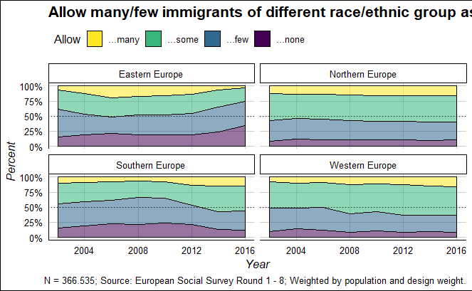

```r
n_imdfetn <- ess1_8$imdfetn %>%
  na.omit %>%
  as.numeric %>%
  length


full_join(cntry_dat, weighted_imm_race_diff, by = "cname") %>%
  filter(!(cname %in% not_wants)) %>%
  na.omit() %>%
  group_by(regional, year, imm_race_diff) %>%
  summarise(perc = mean(perc)) %>%
  ggplot(aes(x = year, y = perc, fill = imm_race_diff, alpha = 0.85)) +
  geom_area(color = "black") +
  geom_hline(yintercept = 0.5, linetype = 3, alpha = 0.9) +
 # geom_line() +
  facet_wrap(~regional, nrow = 2) +
#  ggthemes::scale_fill_gdocs() +
  # disco::scale_fill_disco(palette = "sunset") +
  viridis::scale_fill_viridis(discrete = T, direction = -1) +
  ggthemes::theme_gdocs() +
  ggtitle("Allow many/few immigrants of different race/ethnic group as majority") +
  ylab("Percent") +
  xlab("Year") +
  guides(alpha = F) +
  scale_y_continuous(labels = scales::percent) +
  theme(legend.position = "top", legend.direction = "horizontal", legend.justification = "left") +
  labs(fill = "Allow", caption = paste0("N = ", "366.535",
                                        "; Source: European Social Survey Round 1 - 8; Weighted by population and design weight."))

ggsave(filename = "images/imm_race_diff_regions.png", height = 8, width = 15)
```

### imm_poor

```r
weight_it <- function(country, filter = T) {

if(filter) {
country_enquo <- enquo(country)

filtered <- ess1_8 %>%
        filter(cntryround == !!country_enquo)
}  else {
  filtered <- ess1_8
}

total <- stats::xtabs(filtered$dp_weight ~ filtered$impcntr) %>%
  as_tibble() %>%
  mutate(n = round(n)) %>%
  rename(imm_poor = filtered.impcntr)

df <- stats::xtabs(filtered$dp_weight ~ filtered$impcntr) %>%
  prop.table() %>%
  as_tibble() %>%
  rename(perc = n)  %>%
  rename(imm_poor = filtered.impcntr) %>%
  left_join(total) %>%
  mutate(cntryround = country)

return(df)
}

cntryrounds <- unique(ess1_8$cntryround) %>% dput()
```

```
c("DK_1", "DK_2", "DK_3", "DK_4", "DK_5", "DK_6", "DK_7", "EE_2",
"EE_3", "EE_4", "EE_5", "EE_6", "EE_7", "EE_8", "FI_1", "FI_2",
"FI_3", "FI_4", "FI_5", "FI_6", "FI_7", "FI_8", "IS_2", "IS_6",
"IS_8", "IE_1", "IE_2", "IE_3", "IE_4", "IE_5", "IE_6", "IE_7",
"IE_8", "LV_4", "LT_5", "LT_6", "LT_7", "LT_8", "NO_1", "NO_2",
"NO_3", "NO_4", "NO_5", "NO_6", "NO_7", "NO_8", "SE_1", "SE_2",
"SE_3", "SE_4", "SE_5", "SE_6", "SE_7", "SE_8", "GB_1", "GB_2",
"GB_3", "GB_4", "GB_5", "GB_6", "GB_7", "GB_8", "AL_6", "HR_4",
"HR_5", "GR_1", "GR_2", "GR_4", "GR_5", "IT_1", "IT_6", "IT_8",
"PT_1", "PT_2", "PT_3", "PT_4", "PT_5", "PT_6", "PT_7", "PT_8",
"SI_1", "SI_2", "SI_3", "SI_4", "SI_5", "SI_6", "SI_7", "SI_8",
"ES_1", "ES_2", "ES_3", "ES_4", "ES_5", "ES_6", "ES_7", "ES_8",
"CY_3", "CY_4", "CY_5", "CY_6", "AT_1", "AT_2", "AT_3", "AT_7",
"AT_8", "BE_1", "BE_2", "BE_3", "BE_4", "BE_5", "BE_6", "BE_7",
"BE_8", "FR_1", "FR_2", "FR_3", "FR_4", "FR_5", "FR_6", "FR_7",
"FR_8", "DE_1", "DE_2", "DE_3", "DE_4", "DE_5", "DE_6", "DE_7",
"DE_8", "LU_1", "LU_2", "NL_1", "NL_2", "NL_3", "NL_4", "NL_5",
"NL_6", "NL_7", "NL_8", "CH_1", "CH_2", "CH_3", "CH_4", "CH_5",
"CH_6", "CH_7", "CH_8", "BG_3", "BG_4", "BG_5", "BG_6", "CZ_1",
"CZ_2", "CZ_4", "CZ_5", "CZ_6", "CZ_7", "CZ_8", "HU_1", "HU_2",
"HU_3", "HU_4", "HU_5", "HU_6", "HU_7", "HU_8", "PL_1", "PL_2",
"PL_3", "PL_4", "PL_5", "PL_6", "PL_7", "PL_8", "RO_4", "SK_2",
"SK_3", "SK_4", "SK_5", "SK_6", "UA_2", "UA_3", "UA_4", "UA_5",
"UA_6", "IL_1", "TR_2", "RU_3", "IL_4", "RU_4", "TR_4", "IL_5",
"RU_5", "IL_6", "RU_6", "XK_6", "IL_7", "IL_8", "RU_8")
```

```r
# weight_it("AT_1")

weighted_imm_poor <- cntryrounds %>%
  purrr::map_df(weight_it) # %>%
#  bind_rows(weight_it("All Countries", filter = F))

# 1 Allow many to come and live here
# 2 Allow some
# 3 Allow a few
# 4 Allow none

colorful <- rev(c('#d7191c','#fdae61','#a6d96a','#1a9641'))

weighted_imm_poor  %<>%
  mutate(cntry = str_extract(cntryround, "^.{2}")) %>%
  mutate(round = str_extract(cntryround, "(\\d)+") %>% as.numeric) %>%
  mutate(imm_poor = factor(imm_poor, levels = c("1", "2", "3", "4"),
                           labels = c("...many", "...some", "...few", "...none"))) %>%
  mutate(cname = countrycode::countrycode(cntry, "iso2c", "country.name")) %>%
  mutate(eu = ifelse(cname %in% eu, 1, 0)) %>%
  filter(eu == 1) %>%
  filter(!(cname %in% c("Latvia", "Romania", "Croatia", "Luxembourg"))) %>%
  mutate(year = case_when(
    round == 1 ~ 2002,
    round == 2 ~ 2004,
    round == 3 ~ 2006,
    round == 4 ~ 2008,
    round == 5 ~ 2010,
    round == 6 ~ 2012,
    round == 7 ~ 2014,
    round == 8 ~ 2016,
  ))
```

```
Some values were not matched unambiguously: XK
```

[figure not shown]

```r
weighted_imm_poor %>%
  ggplot(aes(x = year, y = perc, fill = imm_poor, alpha = 0.85)) +
  geom_area(color = "black") +
  geom_hline(yintercept = 0.5, linetype = 3, alpha = 0.9) +
 # geom_line() +
  facet_wrap(~cname, nrow = 5) +
#  ggthemes::scale_fill_gdocs() +
  # scale_fill_manual(values = colorful) +
  viridis::scale_fill_viridis(discrete = T, direction = -1) +
  ggthemes::theme_gdocs() +
  ggtitle("Allow many/few immigrants from poorer countries outside Europe") +
  ylab("Percent") +
  xlab("Year") +
  guides(alpha = F) +
  scale_y_continuous(labels = scales::percent) +
  theme(legend.position = "top", legend.direction = "horizontal", legend.justification = "left") +
  labs(fill = "Allow", caption = paste0("N = ", "364.733",
                                        "; Source: European Social Survey Round 1 - 8; Weighted by population and design weight."))

ggsave(filename = "images/imm_poor.png", height = 8, width = 15)
```

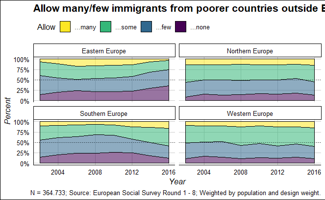

```r
n_impcntr <- ess1_8$impcntr %>%
  na.omit %>%
  as.numeric %>%
  length



full_join(cntry_dat, weighted_imm_poor, by = "cname") %>%
  filter(!(cname %in% not_wants)) %>%
  na.omit() %>%
  group_by(regional, year, imm_poor) %>%
  summarise(perc = mean(perc)) %>%
  ggplot(aes(x = year, y = perc, fill = imm_poor, alpha = 0.85)) +
  geom_area(color = "black") +
  geom_hline(yintercept = 0.5, linetype = 3, alpha = 0.9) +
 # geom_line() +
  facet_wrap(~regional, nrow = 2) +
#  ggthemes::scale_fill_gdocs() +
  # scale_fill_manual(values = colorful) +
  viridis::scale_fill_viridis(discrete = T, direction = -1) +
  ggthemes::theme_gdocs() +
  ggtitle("Allow many/few immigrants from poorer countries outside Europe") +
  ylab("Percent") +
  xlab("Year") +
  guides(alpha = F) +
  scale_y_continuous(labels = scales::percent) +
  theme(legend.position = "top", legend.direction = "horizontal", legend.justification = "left") +
  labs(fill = "Allow", caption = paste0("N = ", "364.733",
                                        "; Source: European Social Survey Round 1 - 8; Weighted by population and design weight."))


ggsave(filename = "images/imm_poor_regions.png", height = 8, width = 15)
```

## 10 scales

### imm_econ

```r
imm_econ_plot <- ess1_8 %>% #filter(cntry == "AT") %>% select(essround) %>% table()
  filter(eu == 1) %>%
  filter(!(cname %in% c("Latvia", "Romania", "Croatia", "Luxembourg"))) %>%
  rename(imm_econ = imbgeco)  %>%
  mutate(year = case_when(
    essround == 1 ~ 2002,
    essround == 2 ~ 2004,
    essround == 3 ~ 2006,
    essround == 4 ~ 2008,
    essround == 5 ~ 2010,
    essround == 6 ~ 2012,
    essround == 7 ~ 2014,
    essround == 8 ~ 2016,
  )) %>%
  # mutate(year = factor(year)) %>%
  group_by(cname, year) %>%
  summarise(imm_econ_wtd = wt.mean(imm_econ, dp_weight),
            imm_econ_sd = wtd.var(imm_econ, dp_weight, na.rm = T) %>% sqrt)

imm_econ_means <- ess1_8 %>% #filter(cntry == "AT") %>% select(essround) %>% table()
  filter(eu == 1) %>%
  filter(!(cname %in% c("Latvia", "Romania", "Croatia", "Luxembourg"))) %>%
  rename(imm_econ = imbgeco)  %>%
  mutate(year = case_when(
    essround == 1 ~ 2002,
    essround == 2 ~ 2004,
    essround == 3 ~ 2006,
    essround == 4 ~ 2008,
    essround == 5 ~ 2010,
    essround == 6 ~ 2012,
    essround == 7 ~ 2014,
    essround == 8 ~ 2016,
  ))  %>%
  group_by(cname) %>%
  summarise(imm_econ_mean = wt.mean(imm_econ, dp_weight))

imm_econ_plot %>%
  ggplot(aes(year, imm_econ_wtd)) +
  geom_point() +
#  geom_hline(data = imm_econ_means, aes(yintercept = mean(imm_econ_mean, na.rm = T), group = cname), linetype = 2) +
 # geom_line() +
  facet_wrap(~cname, nrow = 5) +
#  ggthemes::scale_fill_gdocs() +
  scale_fill_manual(values = colorful) +
  ggthemes::theme_gdocs() +
  ggtitle("Immigration bad or good for country's economy") +
  ylab("0 = Bad for the economy - 10 = Good for the economy") +
  xlab("Year") +
  guides(alpha = F) +
  theme(legend.position = "top", legend.direction = "horizontal", legend.justification = "left") +
  labs(fill = "Allow", caption = paste0("N = ", "361.656",
                                        "; Source: European Social Survey Round 1 - 8; Weighted by population and design weight.")) +
  ylim(0, 10) +
  geom_line() +
  geom_errorbar(aes(ymin = imm_econ_wtd - (imm_econ_sd),
                    ymax = imm_econ_wtd + (imm_econ_sd)),
                colour = "black", width = .1)

ggsave(filename = "images/imm_econ.png", height = 8, width = 15)

n_imbgeco <- ess1_8$imbgeco %>%
  na.omit %>%
  as.numeric %>%
  length



full_join(cntry_dat, imm_econ_plot, by = "cname") %>%
  filter(!(cname %in% not_wants)) %>%
  na.omit() %>%
  group_by(regional, year) %>%
  summarise(imm_econ_wtd = mean(imm_econ_wtd),
            imm_econ_sd = mean(imm_econ_sd))  %>%
  ggplot(aes(year, imm_econ_wtd)) +
  geom_point() +
#  geom_hline(data = imm_econ_means, aes(yintercept = mean(imm_econ_mean, na.rm = T), group = cname), linetype = 2) +
 # geom_line() +
  facet_wrap(~regional, nrow = 2) +
#  ggthemes::scale_fill_gdocs() +
  scale_fill_manual(values = colorful) +
  ggthemes::theme_gdocs() +
  ggtitle("Immigration bad or good for country's economy") +
  ylab("0 = Bad for the economy - 10 = Good for the economy") +
  xlab("Year") +
  guides(alpha = F) +
  theme(legend.position = "top", legend.direction = "horizontal", legend.justification = "left") +
  labs(fill = "Allow", caption = paste0("N = ", "361.656",
                                        "; Source: European Social Survey Round 1 - 8; Weighted by population and design weight.")) +
  ylim(0, 10) +
  geom_line() +
  geom_errorbar(aes(ymin = imm_econ_wtd - (imm_econ_sd),
                    ymax = imm_econ_wtd + (imm_econ_sd)),
                colour = "black", width = .1)

ggsave(filename = "images/imm_econ_regions.png", height = 8, width = 15)
```

### imm_culture

```r
imm_culture_plot <- ess1_8 %>% #filter(cntry == "AT") %>% select(essround) %>% table()
  filter(eu == 1) %>%
  filter(!(cname %in% c("Latvia", "Romania", "Croatia", "Luxembourg"))) %>%
  rename(imm_culture = imueclt)  %>%
  mutate(year = case_when(
    essround == 1 ~ 2002,
    essround == 2 ~ 2004,
    essround == 3 ~ 2006,
    essround == 4 ~ 2008,
    essround == 5 ~ 2010,
    essround == 6 ~ 2012,
    essround == 7 ~ 2014,
    essround == 8 ~ 2016,
  )) %>%
  # mutate(year = factor(year)) %>%
  group_by(cname, year) %>%
  summarise(imm_culture_wtd = wt.mean(imm_culture, dp_weight),
            imm_culture_sd = wtd.var(imm_culture, dp_weight, na.rm = T) %>% sqrt)

imm_culture_means <- ess1_8 %>% #filter(cntry == "AT") %>% select(essround) %>% table()
  filter(eu == 1) %>%
  filter(!(cname %in% c("Latvia", "Romania", "Croatia", "Luxembourg"))) %>%
  rename(imm_culture = imueclt)  %>%
  mutate(year = case_when(
    essround == 1 ~ 2002,
    essround == 2 ~ 2004,
    essround == 3 ~ 2006,
    essround == 4 ~ 2008,
    essround == 5 ~ 2010,
    essround == 6 ~ 2012,
    essround == 7 ~ 2014,
    essround == 8 ~ 2016,
  ))  %>%
  group_by(cname) %>%
  summarise(imm_culture_mean = wt.mean(imm_culture, dp_weight))

imm_culture_plot %>%
  ggplot(aes(year, imm_culture_wtd)) +
  geom_point() +
#  geom_hline(data = imm_culture_means, aes(yintercept = mean(imm_culture_mean, na.rm = T), group = cname), linetype = 2) +
 # geom_line() +
  facet_wrap(~cname, nrow = 5) +
#  ggthemes::scale_fill_gdocs() +
  scale_fill_manual(values = colorful) +
  ggthemes::theme_gdocs() +
  ggtitle("Country's cultural life undermined or enriched by immigrants") +
  ylab("0 = Cultural life undermined - 10 = Cultural life enriched") +
  xlab("Year") +
  guides(alpha = F) +
  theme(legend.position = "top", legend.direction = "horizontal", legend.justification = "left") +
  labs(fill = "Allow", caption = paste0("N = ", "362.497",
                                        "; Source: European Social Survey Round 1 - 8; Weighted by population and design weight.")) +
  ylim(0, 10) +
  geom_line() +
  geom_errorbar(aes(ymin = imm_culture_wtd - (imm_culture_sd),
                    ymax = imm_culture_wtd + (imm_culture_sd)),
                colour = "black", width = .1)

ggsave(filename = "images/imm_culture.png", height = 8, width = 15)

n_imueclt <- ess1_8$imueclt %>%
  na.omit %>%
  as.numeric %>%
  length

full_join(cntry_dat, imm_culture_plot, by = "cname") %>%
  filter(!(cname %in% not_wants)) %>%
  na.omit() %>%
  group_by(regional, year) %>%
  summarise(imm_culture_wtd = mean(imm_culture_wtd),
            imm_culture_sd = mean(imm_culture_sd))  %>%
  ggplot(aes(year, imm_culture_wtd)) +
  geom_point() +
#  geom_hline(data = imm_culture_means, aes(yintercept = mean(imm_culture_mean, na.rm = T), group = cname), linetype = 2) +
 # geom_line() +
  facet_wrap(~regional, nrow = 2) +
#  ggthemes::scale_fill_gdocs() +
  scale_fill_manual(values = colorful) +
  ggthemes::theme_gdocs() +
  ggtitle("Country's cultural life undermined or enriched by immigrants") +
  ylab("0 = Cultural life undermined - 10 = Cultural life enriched") +
  xlab("Year") +
  guides(alpha = F) +
  theme(legend.position = "top", legend.direction = "horizontal", legend.justification = "left") +
  labs(fill = "Allow", caption = paste0("N = ", "362.497",
                                        "; Source: European Social Survey Round 1 - 8; Weighted by population and design weight.")) +
  ylim(0, 10) +
  geom_line() +
  geom_errorbar(aes(ymin = imm_culture_wtd - (imm_culture_sd),
                    ymax = imm_culture_wtd + (imm_culture_sd)),
                colour = "black", width = .1)

ggsave(filename = "images/imm_culture_regions.png", height = 8, width = 15)
```

### imm_worse

```r
imm_worse_plot <- ess1_8 %>% #filter(cntry == "AT") %>% select(essround) %>% table()
  filter(eu == 1) %>%
  filter(!(cname %in% c("Latvia", "Romania", "Croatia", "Luxembourg"))) %>%
  rename(imm_worse = imwbcnt)  %>%
  mutate(year = case_when(
    essround == 1 ~ 2002,
    essround == 2 ~ 2004,
    essround == 3 ~ 2006,
    essround == 4 ~ 2008,
    essround == 5 ~ 2010,
    essround == 6 ~ 2012,
    essround == 7 ~ 2014,
    essround == 8 ~ 2016,
  )) %>%
  # mutate(year = factor(year)) %>%
  group_by(cname, year) %>%
  summarise(imm_worse_wtd = wt.mean(imm_worse, dp_weight),
            imm_worse_sd = wtd.var(imm_worse, dp_weight, na.rm = T) %>% sqrt) %>%
  ungroup %>%
  group_by(cname) %>%
  mutate(imm_worse_mean = mean(imm_worse_wtd))

imm_worse_means <- ess1_8 %>% #filter(cntry == "AT") %>% select(essround) %>% table()
  filter(eu == 1) %>%
  filter(!(cname %in% c("Latvia", "Romania", "Croatia", "Luxembourg"))) %>%
  rename(imm_worse = imwbcnt)  %>%
  mutate(year = case_when(
    essround == 1 ~ 2002,
    essround == 2 ~ 2004,
    essround == 3 ~ 2006,
    essround == 4 ~ 2008,
    essround == 5 ~ 2010,
    essround == 6 ~ 2012,
    essround == 7 ~ 2014,
    essround == 8 ~ 2016,
  ))  %>%
  group_by(cname) %>%
  summarise(imm_worse_mean = wt.mean(imm_worse, dp_weight))

imm_worse_plot %>%
  ggplot(aes(year, imm_worse_wtd)) +
  geom_point() +
 # geom_hline(aes(yintercept = mean(imm_worse_mean, na.rm = T), group = cname), linetype = 2) +
 # geom_line() +
  facet_wrap(~cname, nrow = 5) +
#  ggthemes::scale_fill_gdocs() +
  scale_fill_manual(values = colorful) +
  ggthemes::theme_gdocs() +
  ggtitle("Immigrants make country worse or better place to live") +
  ylab("0 = Worse place to liver - 10 = Better place to live") +
  xlab("Year") +
  guides(alpha = F) +
  theme(legend.position = "top", legend.direction = "horizontal", legend.justification = "left") +
  labs(fill = "Allow", caption = paste0("N = ", "361.001",
                                        "; Source: European Social Survey Round 1 - 8; Weighted by population and design weight.")) +
  ylim(0, 10) +
  geom_line(size = 0.6) +
  geom_errorbar(aes(ymin = imm_worse_wtd - (imm_worse_sd),
                    ymax = imm_worse_wtd + (imm_worse_sd)),
                colour = "black", width = .1)

ggsave(filename = "images/imm_worse.png", height = 8, width = 15)

n_imwbcnt <- ess1_8$imwbcnt %>%
  na.omit %>%
  as.numeric %>%
  length


full_join(cntry_dat, imm_worse_plot, by = "cname") %>%
  filter(!(cname %in% not_wants)) %>%
  na.omit() %>%
  group_by(regional, year) %>%
  summarise(imm_worse_wtd = mean(imm_worse_wtd),
            imm_worse_sd = mean(imm_worse_sd))  %>%
  ggplot(aes(year, imm_worse_wtd)) +
  geom_point() +
#  geom_hline(data = imm_worse_means, aes(yintercept = mean(imm_worse_mean, na.rm = T), group = cname), linetype = 2) +
 # geom_line() +
  facet_wrap(~regional, nrow = 2) +
#  ggthemes::scale_fill_gdocs() +
  scale_fill_manual(values = colorful) +
  ggthemes::theme_gdocs() +
  ggtitle("Immigrants make country worse or better place to live") +
  ylab("0 = Worse place to liver - 10 = Better place to live") +
  xlab("Year") +
  guides(alpha = F) +
  theme(legend.position = "top", legend.direction = "horizontal", legend.justification = "left") +
  labs(fill = "Allow", caption = paste0("N = ", "361.001",
                                        "; Source: European Social Survey Round 1 - 8; Weighted by population and design weight.")) +
  ylim(0, 10) +
  geom_line() +
  geom_errorbar(aes(ymin = imm_worse_wtd - (imm_worse_sd),
                    ymax = imm_worse_wtd + (imm_worse_sd)),
                colour = "black", width = .1)

ggsave(filename = "images/imm_worse_regions.png", height = 8, width = 15)
```

## regions

```r
cntry_dat <- bind_rows(
data.frame(stringsAsFactors=FALSE,
          cname = c("Denmark", "Estonia", "Faroe Islands", "Finland", "Iceland",
                 "Ireland", "Isle of Man", "Latvia", "Lithuania", "Norway",
                 "Svalbard and Jan Mayen Islands", "Sweden",
                 "United Kingdom"),
          regional = "Northern Europe"),
data.frame(stringsAsFactors=FALSE,
          cname = c("Albania", "Andorra", "Bosnia and Herzegovina",
                   "Croatia", "Gibraltar", "Greece", "Holy See", "Italy",
                   "Malta", "Montenegro", "Portugal", "San Marino", "Serbia",
                   "Slovenia", "Spain", "Cyprus",
                   "The former Yugoslav Republic of Macedonia"),
          regional = "Southern Europe"),
data.frame(stringsAsFactors=FALSE,
          cname = c("Austria", "Belgium", "France", "Germany",
                    "Liechtenstein", "Luxembourg", "Monaco", "Netherlands",
                    "Switzerland"),
          regional = "Western Europe"),
data.frame(stringsAsFactors=FALSE,
           cname = c("Belarus", "Bulgaria", "Czechia", "Hungary", "Poland",
                     "Republic of Moldova", "Romania", "Russian Federation", "Slovakia",
                     "Ukraine"),
           regional = "Eastern Europe")
)

not_wants <- c("Andorra", "Belarus", "Bosnia and Herzegovina", "Faroe Islands", "Gibraltar", "Holy See", "Isle of Man", "Liechtenstein", "Malta", "Monaco", "Montenegro", "Republic of Moldova", "Russian Federation", "San Marino", "Serbia", "Svalbard and Jan Mayen Islands", "The former Yugoslav Republic of Macedonia")


# https://unstats.un.org/unsd/methodology/m49/

# cntry_dat %<>%
  # mutate(cntry = countrycode::countrycode(cntry, "country.name", "country.name"))

# uk <- mlogit_ess %>%
#   filter(cntry == "United Kingdom") %>%
#   mutate(regional = "north")


ess1_8 <- full_join(cntry_dat, ess1_8, by = "cname")

ess1_8 %<>%
  filter(!(cname %in% not_wants))

# mlogit_ess <- rbind(mlogit_ess, uk)

ess1_8 %<>%
  mutate(north = ifelse(regional == "north", 1, 0)) %>%
  mutate(south = ifelse(regional == "south", 1, 0)) %>%
  mutate(east = ifelse(regional == "east", 1, 0)) %>%
  mutate(west = ifelse(regional == "west", 1, 0))
```

### imm_race

```r
weight_it <- function(country, filter = T) {

if(filter) {
country_enquo <- enquo(country)

filtered <- ess1_8 %>%
        filter(regionround == !!country_enquo)
}  else {
  filtered <- ess1_8
}

total <- stats::xtabs(filtered$dp_weight ~ filtered$imsmetn) %>%
  as_tibble() %>%
  mutate(n = round(n)) %>%
  rename(imm_race = filtered.imsmetn)

df <- stats::xtabs(filtered$dp_weight ~ filtered$imsmetn) %>%
  prop.table() %>%
  as_tibble() %>%
  rename(perc = n)  %>%
  rename(imm_race = filtered.imsmetn) %>%
  left_join(total) %>%
  mutate(cntryround = country)

return(df)
}


ess1_8 %<>%
  mutate(regionround = paste(regional, essround, sep = "_"))

ess1_8 %>%
  select(regional, cname) %>% table()

ess1_8 %>%
  group_by(cname) %>%
  count() %>% arrange(n)

regionrounds <- unique(ess1_8$regionround) %>% dput()

regionrounds %<>% str_remove_all(pattern = "NA_*.") %>% .[1:32]

region_imm_race <- regionrounds %>%
  purrr::map_df(weight_it) # %>%
#  bind_rows(weight_it("All Countries", filter = F))

# 1 Allow many to come and live here
# 2 Allow some
# 3 Allow a few
# 4 Allow none

colorful <- rev(c('#d7191c','#fdae61','#a6d96a','#1a9641'))

weighted_imm_race  %<>%
  mutate(cntry = str_extract(cntryround, "^.{2}")) %>%
  mutate(round = str_extract(cntryround, "(\\d)+") %>% as.numeric) %>%
  mutate(imm_race = factor(imm_race, levels = c("1", "2", "3", "4"),
                           labels = c("...many", "...some", "...few", "...none"))) %>%
  mutate(cname = countrycode::countrycode(cntry, "iso2c", "country.name")) %>%
  mutate(eu = ifelse(cname %in% eu, 1, 0)) %>%
  filter(eu == 1) %>%
  filter(!(cname %in% c("Latvia", "Romania", "Croatia", "Luxembourg"))) %>%
  mutate(year = case_when(
    round == 1 ~ 2002,
    round == 2 ~ 2004,
    round == 3 ~ 2006,
    round == 4 ~ 2008,
    round == 5 ~ 2010,
    round == 6 ~ 2012,
    round == 7 ~ 2014,
    round == 8 ~ 2016,
  ))

weighted_imm_race %>%
  ggplot(aes(x = year, y = perc, fill = imm_race, alpha = 0.85)) +
  geom_area(color = "black") +
  geom_hline(yintercept = 0.5, linetype = 3, alpha = 0.9) +
#  geom_point(shape = 6, alpha = 0.85, position = "identity") +
  facet_wrap(~cname, nrow = 5) +
#  ggthemes::scale_fill_gdocs() +
  scale_fill_manual(values = colorful) +
  ggthemes::theme_gdocs() +
  ggtitle("Allow many/few immigrants of same race/ethnic group as majority") +
  ylab("Percent") +
  xlab("Year") +
  guides(alpha = F) +
  scale_y_continuous(labels = scales::percent) +
  theme(legend.position = "top", legend.direction = "horizontal", legend.justification = "left") +
  labs(fill = "Allow", caption = paste0("N = ", "367.527",
                                        "; Source: European Social Survey Round 1 - 8; Weighted by population and design weight."))

ggsave(filename = "images/imm_race.png", height = 8, width = 15)
```

## tables

```r
load("data/ess1_8_list.Rdata")

ess1_8_list %>%
  purrr::map_df(~{var_names(.x, "migr|fugee|asyl") %>%
      mutate(round = .x$essround %>% unique)}) -> mig_dat
```

## selected countries

```r
eu <- c("Austria", "Italy", "Belgium", "Latvia", "Bulgaria", "Lithuania", "Croatia", "Luxembourg", "Cyprus", "Malta", "Czechia", "Netherlands", "Denmark", "Poland", "Estonia", "Portugal", "Finland", "Romania", "France", "Slovakia", "Germany", "Slovenia", "Greece", "Spain", "Hungary", "Sweden", "Ireland", "United Kingdom")


yeardat <- mig_dat %>%
  spread("round", "var_names") %>%
  mutate(na_count = 8 - rowSums(is.na(.))) %>%
  arrange(desc(na_count)) %>%
#  filter(na_count > 1) %>%   # filtering out the questions that have been asked in only one survey
  select(var_codes, na_count, everything()) %>%
  mutate_at(vars(3:10), function(x){ifelse(is.na(x), 0, 1)}) %>%
  left_join(mig_dat %>% select(var_codes, var_names) %>% group_by(var_codes) %>% slice(1)) %>%
  select(var_codes, var_names, everything(), n_survey = na_count)


get_presencies <- function(x, country) {
x %>%
  filter(cntry == country) %>%
  select(matches(yeardat$var_codes %>% paste(., collapse = "|"))) %>%
  colSums(is.na(.))  %>% as.list() %>% data.frame() %>%
  t() %>% as.data.frame() %>% rownames_to_column("var_codes") %>%
  rename(present = V1) %>%
  mutate(present = ifelse(is.na(present), 0, 1)) %>%
  mutate(cntry = country) %>%
  mutate(cname = countrycode::countrycode(cntry, "iso2c", "country.name")) %>%
  mutate(eu = ifelse(cname %in% eu, 1, 0)) %>%
  filter(eu == 1) %>%
  select(-eu)
}

mig_full <- bind_rows(
ess1_8_list[[1]]$cntry %>% unique() %>%
  map_df(~{
    get_presencies(x = ess1_8_list[[1]], country = .x)
  }) %>%
  mutate(round = 1),
ess1_8_list[[2]]$cntry %>% unique() %>%
  map_df(~{
    get_presencies(x = ess1_8_list[[2]], country = .x)
  }) %>%
  mutate(round = 2),
ess1_8_list[[3]]$cntry %>% unique() %>%
  map_df(~{
    get_presencies(x = ess1_8_list[[3]], country = .x)
  }) %>%
  mutate(round = 3),
ess1_8_list[[4]]$cntry %>% unique() %>%
  map_df(~{
    get_presencies(x = ess1_8_list[[4]], country = .x)
  }) %>%
  mutate(round = 4),
ess1_8_list[[5]]$cntry %>% unique() %>%
  map_df(~{
    get_presencies(x = ess1_8_list[[5]], country = .x)
  }) %>%
  mutate(round = 5),
ess1_8_list[[6]]$cntry %>% unique() %>%
  map_df(~{
    get_presencies(x = ess1_8_list[[6]], country = .x)
  }) %>%
  mutate(round = 6),
ess1_8_list[[7]]$cntry %>% unique() %>%
  map_df(~{
    get_presencies(x = ess1_8_list[[7]], country = .x)
  }) %>%
  mutate(round = 7),
ess1_8_list[[8]]$cntry %>% unique() %>%
  map_df(~{
    get_presencies(x = ess1_8_list[[8]], country = .x)
  }) %>%
  mutate(round = 8)
)

mig_full %<>%
  select(-cntry) %>%
  # group_by(var_codes, cntry, round) %>%
  # mutate(n = n())
  spread("round", "present") %>%
  mutate(n_surveycntry = 8 - rowSums(is.na(.))) %>%
  full_join(yeardat %>% select(var_codes, var_names, n_survey)) %>%
#  group_by(cntry) %>%
#  mutate(cntry_n = n()) %>%
  # add_count(var_codes) %>%
  # rename(cntry_n = n) %>%
  arrange(var_codes, desc(n_survey), cname) %>%
  select(cname, var_codes, var_names,
         n_survey, n_surveycntry,
         everything()) %>%
  mutate_at(vars(4:13), function(x){ifelse(is.na(x) | x == 0, 0, 1)}) %>%
  rename(`2002` = `1`,
         `2004` = `2`,
         `2006` = `3`,
         `2008` = `4`,
         `2010` = `5`,
         `2012` = `6`,
         `2014` = `7`,
         `2016` = `8`,
         )


ess_migrant <- mig_full %>%
  mutate(n_cntryear = mig_full[,6:13] %>%
  rowSums()) %>%
  select(-n_survey, -n_surveycntry) %>%
  filter(n_cntryear > 1) %>%
  arrange(cname, desc(n_cntryear))

xlsx::write.xlsx(ess_migrant, file = "data/ess_migrant.xlsx", sheetName = "Full Data")

ess_migrant_others <- ess_migrant %>%
  filter(!(var_codes %in% c("imbgeco", "imdfetn", "impcntr", "imsmetn", "imueclt", "imwbcnt"))) %>%
  arrange(cname, desc(n_cntryear))


xlsx::write.xlsx(ess_migrant_others, file = "data/ess_migrant.xlsx", sheetName = "Others", append = T)
```

## pooled

13 countries have six questions asked accross all survey round

They are:

“Belgium”, “Germany”, “Spain”, “Finland”, “France”, “United Kingdom”, “Hungary”, “Ireland”, “Netherlands”, “Poland”, “Portugal”, “Sweden”, “Slovenia”

| var_codes | var_names | n |
| --- | --- | --- |
| imbgeco | Immigration bad or good for country's economy | 13 |
| imdfetn | Allow many/few immigrants of different race/ethnic group from majority | 13 |
| impcntr | Allow many/few immigrants from poorer countries outside Europe | 13 |
| imsmetn | Allow many/few immigrants of same race/ethnic group as majority | 13 |
| imueclt | Country's cultural life undermined or enriched by immigrants | 13 |
| imwbcnt | Immigrants make country worse or better place to live | 13 |

```r
# ess1_8_list[[8]]$cntry %>% unique() %>%
  # map_df(get_presencies)
```

## Tables for Pub

1 Allow many to come and live here  
2 Allow some 3 Allow a few 4 Allow none 7 Refusal 8 Don’t know 9 No answer

0 Bad for the economy 1 2 3 4 5 6 7 8 9 10 Good for the economy 77 Refusal 88 Don’t know 99 No answer

### data

```r
eu <- c("Austria", "Italy", "Belgium", "Latvia", "Bulgaria", "Lithuania", "Croatia", "Luxembourg", "Cyprus", "Malta", "Czechia", "Netherlands", "Denmark", "Poland", "Estonia", "Portugal", "Finland", "Romania", "France", "Slovakia", "Germany", "Slovenia", "Greece", "Spain", "Hungary", "Sweden", "Ireland", "United Kingdom")


ess1_8_table %<>%
  mutate(dp_weight = pweight * dweight) %>%
  mutate(cntryround = paste(cntry, essround, sep = "_")) %>%
  mutate(cname = countrycode::countrycode(cntry, "iso2c", "country.name")) %>%
  mutate(eu = ifelse(cname %in% eu, 1, 0))
```

```
Some values were not matched unambiguously: XK
```

```r
tidytemplate::save_it(ess1_8_table)
```

### helpter function

```r
weight_em <- function(x, group, wt) {
weighted_total <- wtd.table(group,
                            weights = wt) %>% as.numeric

dat <- wtd.table(x,
          group,
          weights = wt) %>%
  as_tibble() %>%
  rename(imm_race = Var1) %>%
  rename(round = Var2) %>%
  mutate(perc = case_when(
    round == 1 ~ n / weighted_total[1],
    round == 2 ~ n / weighted_total[2],
    round == 3 ~ n / weighted_total[3],
    round == 4 ~ n / weighted_total[4],
    round == 5 ~ n / weighted_total[5],
    round == 6 ~ n / weighted_total[6],
    round == 7 ~ n / weighted_total[7],
    round == 8 ~ n / weighted_total[8]
  )) %>%
  mutate(year = case_when(
    round == 1 ~ 2002,
    round == 2 ~ 2004,
    round == 3 ~ 2006,
    round == 4 ~ 2008,
    round == 5 ~ 2010,
    round == 6 ~ 2012,
    round == 7 ~ 2014,
    round == 8 ~ 2016,
  ))

return(dat)
}

# data <- ess1_8_west_table %>%
#             select(imsmetn, essround, dp_weight)

get_table <- function(data, levels = NULL, labels = NULL) {

wt <- weight_em(data[,1][[1]],
                data[,2][[1]],
                data[,3][[1]])

n_years <- wt %>%
  group_by(year) %>%
  summarise(n = sum(n)) %>% t %>% .[2,] %>% round(.) %>%
  c("N", .)


wt_table <- wt %>%
  select(-n, -round) %>%
  mutate(perc2 = (perc * 100) %>%
                round(.)) %>%
  mutate(perc2 = ifelse(perc == 0, "", perc2)) %>%
  mutate(perc2 = ifelse(perc < 0.005, "*", perc2)) %>%
  select(-perc) %>%
  rename(perc = perc2) %>%
  spread(year, perc) %>%
  mutate(imm_race = as.character(imm_race)) %>%
  rbind(., n_years) %>%
  rbind(c("", rep("%", 8)), .) %>%
  mutate(imm_race = factor(imm_race,
                           levels = levels,
                           labels = labels)) %>%
  mutate(imm_race = as.character(imm_race))

return(wt_table)
}
```

### imm_race (imsmetn)

#### pooled

```r
ess1_8_table <- tidytemplate::load_it("data/ess1_8_table.Rdata")

ess_pooled <- c("Belgium", "Germany", "Spain", "Finland",
"France", "United Kingdom", "Hungary", "Ireland", "Netherlands",
"Poland", "Portugal", "Sweden", "Slovenia")

ess1_8_pooled_table <- ess1_8_table %>%
  filter(cname %in% ess_pooled)

levels <- c("1", "2", "3", "4", "7", "8", "9", "", "N")

labels <- c("...many to come and live here",
           "...some", "...a few", "...none",
           "Refusal", "Don't Know", "No answer", "", "N")

imm_race_pooled <- get_table(ess1_8_pooled_table %>%
                          select(imsmetn, essround, dp_weight),
                           levels, labels)
```

```
the condition has length > 1 and only the first element will be used
```

```r
stargazer::stargazer(imm_race_pooled, summary = F,
                     #note you have to specify type
                     type = "html",
                     #note that the argument is "out" not "file"
                     out="tables/singles/imm_race_pooled.doc", rownames = F)
```

```
<table style="text-align:center"><tr><td colspan="9" style="border-bottom: 1px solid black"></td></tr><tr><td style="text-align:left">imm_race</td><td>2002</td><td>2004</td><td>2006</td><td>2008</td><td>2010</td><td>2012</td><td>2014</td><td>2016</td></tr>
<tr><td colspan="9" style="border-bottom: 1px solid black"></td></tr><tr><td style="text-align:left"></td><td>%</td><td>%</td><td>%</td><td>%</td><td>%</td><td>%</td><td>%</td><td>%</td></tr>
<tr><td style="text-align:left">...many to come and live here</td><td>15</td><td>18</td><td>18</td><td>20</td><td>19</td><td>23</td><td>24</td><td>26</td></tr>
<tr><td style="text-align:left">...some</td><td>48</td><td>46</td><td>46</td><td>46</td><td>47</td><td>48</td><td>47</td><td>49</td></tr>
<tr><td style="text-align:left">...a few</td><td>27</td><td>25</td><td>27</td><td>24</td><td>24</td><td>21</td><td>20</td><td>17</td></tr>
<tr><td style="text-align:left">...none</td><td>6</td><td>8</td><td>8</td><td>7</td><td>7</td><td>6</td><td>6</td><td>5</td></tr>
<tr><td style="text-align:left">Refusal</td><td>*</td><td>*</td><td>*</td><td>*</td><td>*</td><td>*</td><td>1</td><td>1</td></tr>
<tr><td style="text-align:left">Don't Know</td><td>4</td><td>2</td><td>2</td><td>2</td><td>3</td><td>2</td><td>2</td><td>2</td></tr>
<tr><td style="text-align:left">No answer</td><td>*</td><td>*</td><td>*</td><td>*</td><td>*</td><td>*</td><td>*</td><td>*</td></tr>
<tr><td style="text-align:left">N</td><td>28655</td><td>29149</td><td>29602</td><td>29994</td><td>30398</td><td>30656</td><td>30925</td><td>31022</td></tr>
<tr><td colspan="9" style="border-bottom: 1px solid black"></td></tr></table>
```

#### western

```r
ess_western <- c("Belgium", "Germany", "Spain", "Finland",
                 "France", "United Kingdom", "Ireland", "Netherlands",
                 "Portugal", "Sweden")

ess1_8_west_table <- ess1_8_table %>%
  filter(cname %in% ess_western)

imm_race_west <- get_table(ess1_8_west_table %>%
                             select(imsmetn, essround, dp_weight),
                           levels, labels)
```

```
the condition has length > 1 and only the first element will be used
```

```r
stargazer::stargazer(imm_race_west, summary = F,
                     #note you have to specify type
                     type = "html",
                     #note that the argument is "out" not "file"
                     out="tables/singles/imm_race_west.doc", rownames = F)
```

```
<table style="text-align:center"><tr><td colspan="9" style="border-bottom: 1px solid black"></td></tr><tr><td style="text-align:left">imm_race</td><td>2002</td><td>2004</td><td>2006</td><td>2008</td><td>2010</td><td>2012</td><td>2014</td><td>2016</td></tr>
<tr><td colspan="9" style="border-bottom: 1px solid black"></td></tr><tr><td style="text-align:left"></td><td>%</td><td>%</td><td>%</td><td>%</td><td>%</td><td>%</td><td>%</td><td>%</td></tr>
<tr><td style="text-align:left">...many to come and live here</td><td>15</td><td>17</td><td>16</td><td>19</td><td>18</td><td>22</td><td>25</td><td>28</td></tr>
<tr><td style="text-align:left">...some</td><td>49</td><td>46</td><td>46</td><td>47</td><td>47</td><td>48</td><td>48</td><td>50</td></tr>
<tr><td style="text-align:left">...a few</td><td>26</td><td>26</td><td>28</td><td>25</td><td>25</td><td>21</td><td>19</td><td>16</td></tr>
<tr><td style="text-align:left">...none</td><td>6</td><td>8</td><td>8</td><td>7</td><td>8</td><td>6</td><td>6</td><td>4</td></tr>
<tr><td style="text-align:left">Refusal</td><td>*</td><td>*</td><td>*</td><td>*</td><td>*</td><td>*</td><td>1</td><td>1</td></tr>
<tr><td style="text-align:left">Don't Know</td><td>4</td><td>2</td><td>1</td><td>2</td><td>2</td><td>2</td><td>2</td><td>2</td></tr>
<tr><td style="text-align:left">No answer</td><td>*</td><td>*</td><td>*</td><td>*</td><td>*</td><td>*</td><td>*</td><td>*</td></tr>
<tr><td style="text-align:left">N</td><td>24519</td><td>24966</td><td>25381</td><td>25744</td><td>26130</td><td>26357</td><td>26272</td><td>26780</td></tr>
<tr><td colspan="9" style="border-bottom: 1px solid black"></td></tr></table>
```

#### eastern

```r
ess_eastern <- c("Hungary", "Poland", "Slovenia")

ess1_8_east_table <- ess1_8_table %>%
  filter(cname %in% ess_eastern)

imm_race_east <- get_table(ess1_8_east_table %>%
                             select(imsmetn, essround, dp_weight),
                           levels, labels)
```

```
the condition has length > 1 and only the first element will be used
```

```r
stargazer::stargazer(imm_race_east, summary = F,
                     #note you have to specify type
                     type = "html",
                     #note that the argument is "out" not "file"
                     out="tables/singles/imm_race_east.doc", rownames = F)
```

```
<table style="text-align:center"><tr><td colspan="9" style="border-bottom: 1px solid black"></td></tr><tr><td style="text-align:left">imm_race</td><td>2002</td><td>2004</td><td>2006</td><td>2008</td><td>2010</td><td>2012</td><td>2014</td><td>2016</td></tr>
<tr><td colspan="9" style="border-bottom: 1px solid black"></td></tr><tr><td style="text-align:left"></td><td>%</td><td>%</td><td>%</td><td>%</td><td>%</td><td>%</td><td>%</td><td>%</td></tr>
<tr><td style="text-align:left">...many to come and live here</td><td>14</td><td>21</td><td>27</td><td>28</td><td>29</td><td>26</td><td>19</td><td>15</td></tr>
<tr><td style="text-align:left">...some</td><td>45</td><td>43</td><td>44</td><td>46</td><td>45</td><td>43</td><td>44</td><td>43</td></tr>
<tr><td style="text-align:left">...a few</td><td>29</td><td>24</td><td>19</td><td>19</td><td>17</td><td>21</td><td>26</td><td>27</td></tr>
<tr><td style="text-align:left">...none</td><td>5</td><td>9</td><td>7</td><td>5</td><td>5</td><td>6</td><td>7</td><td>13</td></tr>
<tr><td style="text-align:left">Refusal</td><td>*</td><td>*</td><td>*</td><td>*</td><td>*</td><td>*</td><td>*</td><td>*</td></tr>
<tr><td style="text-align:left">Don't Know</td><td>7</td><td>3</td><td>3</td><td>3</td><td>3</td><td>4</td><td>3</td><td>2</td></tr>
<tr><td style="text-align:left">No answer</td><td>*</td><td>*</td><td>*</td><td>*</td><td>*</td><td>*</td><td>*</td><td>*</td></tr>
<tr><td style="text-align:left">N</td><td>4136</td><td>4183</td><td>4221</td><td>4250</td><td>4268</td><td>4300</td><td>4654</td><td>4242</td></tr>
<tr><td colspan="9" style="border-bottom: 1px solid black"></td></tr></table>
```

### imm_race_diff (imdfetn)

#### pooled

```r
ess_pooled <- c("Belgium", "Germany", "Spain", "Finland",
"France", "United Kingdom", "Hungary", "Ireland", "Netherlands",
"Poland", "Portugal", "Sweden", "Slovenia")

ess1_8_pooled_table <- ess1_8_table %>%
  filter(cname %in% ess_pooled)

levels <- c("1", "2", "3", "4", "7", "8", "9", "", "N")

labels <- c("...many to come and live here",
           "...some", "...a few", "...none",
           "Refusal", "Don't Know", "No answer", "", "N")

imm_race_diff_pooled <- get_table(ess1_8_pooled_table %>%
                          select(imdfetn, essround, dp_weight),
                           levels, labels)
```

```
the condition has length > 1 and only the first element will be used
```

```r
stargazer::stargazer(imm_race_diff_pooled, summary = F,
                     #note you have to specify type
                     type = "html",
                     #note that the argument is "out" not "file"
                     out="tables/singles/imm_race_diff_pooled.doc", rownames = F)
```

```
<table style="text-align:center"><tr><td colspan="9" style="border-bottom: 1px solid black"></td></tr><tr><td style="text-align:left">imm_race</td><td>2002</td><td>2004</td><td>2006</td><td>2008</td><td>2010</td><td>2012</td><td>2014</td><td>2016</td></tr>
<tr><td colspan="9" style="border-bottom: 1px solid black"></td></tr><tr><td style="text-align:left"></td><td>%</td><td>%</td><td>%</td><td>%</td><td>%</td><td>%</td><td>%</td><td>%</td></tr>
<tr><td style="text-align:left">...many to come and live here</td><td>10</td><td>12</td><td>11</td><td>13</td><td>13</td><td>15</td><td>16</td><td>18</td></tr>
<tr><td style="text-align:left">...some</td><td>41</td><td>40</td><td>39</td><td>42</td><td>41</td><td>43</td><td>44</td><td>45</td></tr>
<tr><td style="text-align:left">...a few</td><td>34</td><td>33</td><td>34</td><td>31</td><td>32</td><td>28</td><td>27</td><td>26</td></tr>
<tr><td style="text-align:left">...none</td><td>10</td><td>13</td><td>13</td><td>11</td><td>11</td><td>10</td><td>10</td><td>9</td></tr>
<tr><td style="text-align:left">Refusal</td><td>*</td><td>*</td><td>*</td><td>*</td><td>*</td><td>*</td><td>*</td><td>1</td></tr>
<tr><td style="text-align:left">Don't Know</td><td>4</td><td>2</td><td>2</td><td>2</td><td>3</td><td>2</td><td>2</td><td>2</td></tr>
<tr><td style="text-align:left">No answer</td><td>*</td><td>*</td><td>*</td><td>*</td><td>*</td><td>*</td><td>*</td><td>*</td></tr>
<tr><td style="text-align:left">N</td><td>28655</td><td>29149</td><td>29602</td><td>29994</td><td>30398</td><td>30656</td><td>30925</td><td>31022</td></tr>
<tr><td colspan="9" style="border-bottom: 1px solid black"></td></tr></table>
```

#### western

```r
ess_western <- c("Belgium", "Germany", "Spain", "Finland",
                 "France", "United Kingdom", "Ireland", "Netherlands",
                 "Portugal", "Sweden")

ess1_8_west_table <- ess1_8_table %>%
  filter(cname %in% ess_western)

imm_race_diff_west <- get_table(ess1_8_west_table %>%
                             select(imdfetn, essround, dp_weight),
                           levels, labels)
```

```
the condition has length > 1 and only the first element will be used
```

```r
stargazer::stargazer(imm_race_diff_west, summary = F,
                     #note you have to specify type
                     type = "html",
                     #note that the argument is "out" not "file"
                     out="tables/singles/imm_race_diff_west.doc", rownames = F)
```

```
<table style="text-align:center"><tr><td colspan="9" style="border-bottom: 1px solid black"></td></tr><tr><td style="text-align:left">imm_race</td><td>2002</td><td>2004</td><td>2006</td><td>2008</td><td>2010</td><td>2012</td><td>2014</td><td>2016</td></tr>
<tr><td colspan="9" style="border-bottom: 1px solid black"></td></tr><tr><td style="text-align:left"></td><td>%</td><td>%</td><td>%</td><td>%</td><td>%</td><td>%</td><td>%</td><td>%</td></tr>
<tr><td style="text-align:left">...many to come and live here</td><td>10</td><td>11</td><td>10</td><td>12</td><td>12</td><td>15</td><td>17</td><td>20</td></tr>
<tr><td style="text-align:left">...some</td><td>42</td><td>40</td><td>40</td><td>43</td><td>41</td><td>44</td><td>46</td><td>48</td></tr>
<tr><td style="text-align:left">...a few</td><td>33</td><td>33</td><td>35</td><td>32</td><td>32</td><td>29</td><td>26</td><td>24</td></tr>
<tr><td style="text-align:left">...none</td><td>10</td><td>13</td><td>13</td><td>11</td><td>11</td><td>10</td><td>9</td><td>6</td></tr>
<tr><td style="text-align:left">Refusal</td><td>*</td><td>*</td><td>*</td><td>1</td><td>*</td><td>1</td><td>1</td><td>1</td></tr>
<tr><td style="text-align:left">Don't Know</td><td>4</td><td>2</td><td>2</td><td>2</td><td>2</td><td>2</td><td>2</td><td>2</td></tr>
<tr><td style="text-align:left">No answer</td><td>*</td><td>*</td><td>*</td><td>*</td><td>*</td><td>*</td><td>*</td><td>*</td></tr>
<tr><td style="text-align:left">N</td><td>24519</td><td>24966</td><td>25381</td><td>25744</td><td>26130</td><td>26357</td><td>26272</td><td>26780</td></tr>
<tr><td colspan="9" style="border-bottom: 1px solid black"></td></tr></table>
```

#### eastern

```r
ess_eastern <- c("Hungary", "Poland", "Slovenia")

ess1_8_east_table <- ess1_8_table %>%
  filter(cname %in% ess_eastern)

imm_race_diff_east <- get_table(ess1_8_east_table %>%
                             select(imdfetn, essround, dp_weight),
                           levels, labels)
```

```
the condition has length > 1 and only the first element will be used
```

```r
stargazer::stargazer(imm_race_diff_east, summary = F,
                     #note you have to specify type
                     type = "html",
                     #note that the argument is "out" not "file"
                     out="tables/singles/imm_race_diff_east.doc", rownames = F)
```

```
<table style="text-align:center"><tr><td colspan="9" style="border-bottom: 1px solid black"></td></tr><tr><td style="text-align:left">imm_race</td><td>2002</td><td>2004</td><td>2006</td><td>2008</td><td>2010</td><td>2012</td><td>2014</td><td>2016</td></tr>
<tr><td colspan="9" style="border-bottom: 1px solid black"></td></tr><tr><td style="text-align:left"></td><td>%</td><td>%</td><td>%</td><td>%</td><td>%</td><td>%</td><td>%</td><td>%</td></tr>
<tr><td style="text-align:left">...many to come and live here</td><td>8</td><td>13</td><td>19</td><td>19</td><td>18</td><td>19</td><td>12</td><td>5</td></tr>
<tr><td style="text-align:left">...some</td><td>36</td><td>38</td><td>37</td><td>39</td><td>41</td><td>39</td><td>37</td><td>29</td></tr>
<tr><td style="text-align:left">...a few</td><td>39</td><td>31</td><td>27</td><td>27</td><td>27</td><td>27</td><td>33</td><td>40</td></tr>
<tr><td style="text-align:left">...none</td><td>11</td><td>14</td><td>14</td><td>12</td><td>11</td><td>10</td><td>14</td><td>23</td></tr>
<tr><td style="text-align:left">Refusal</td><td>*</td><td>*</td><td>*</td><td>*</td><td>*</td><td>*</td><td>*</td><td>*</td></tr>
<tr><td style="text-align:left">Don't Know</td><td>7</td><td>3</td><td>3</td><td>3</td><td>4</td><td>4</td><td>4</td><td>2</td></tr>
<tr><td style="text-align:left">No answer</td><td>*</td><td>*</td><td>*</td><td>*</td><td>*</td><td>*</td><td>*</td><td>*</td></tr>
<tr><td style="text-align:left">N</td><td>4136</td><td>4183</td><td>4221</td><td>4250</td><td>4268</td><td>4300</td><td>4654</td><td>4242</td></tr>
<tr><td colspan="9" style="border-bottom: 1px solid black"></td></tr></table>
```

### imm_poor (impcntr)

#### pooled

```r
ess_pooled <- c("Belgium", "Germany", "Spain", "Finland",
"France", "United Kingdom", "Hungary", "Ireland", "Netherlands",
"Poland", "Portugal", "Sweden", "Slovenia")

ess1_8_pooled_table <- ess1_8_table %>%
  filter(cname %in% ess_pooled)

levels <- c("1", "2", "3", "4", "7", "8", "9", "", "N")

labels <- c("...many to come and live here",
           "...some", "...a few", "...none",
           "Refusal", "Don't Know", "No answer", "", "N")

imm_poor_pooled <- get_table(ess1_8_pooled_table %>%
                          select(impcntr, essround, dp_weight),
                           levels, labels)
```

```
the condition has length > 1 and only the first element will be used
```

```r
stargazer::stargazer(imm_poor_pooled, summary = F,
                     #note you have to specify type
                     type = "html",
                     #note that the argument is "out" not "file"
                     out="tables/singles/imm_poor_pooled.doc", rownames = F)
```

```
<table style="text-align:center"><tr><td colspan="9" style="border-bottom: 1px solid black"></td></tr><tr><td style="text-align:left">imm_race</td><td>2002</td><td>2004</td><td>2006</td><td>2008</td><td>2010</td><td>2012</td><td>2014</td><td>2016</td></tr>
<tr><td colspan="9" style="border-bottom: 1px solid black"></td></tr><tr><td style="text-align:left"></td><td>%</td><td>%</td><td>%</td><td>%</td><td>%</td><td>%</td><td>%</td><td>%</td></tr>
<tr><td style="text-align:left">...many to come and live here</td><td>10</td><td>11</td><td>12</td><td>13</td><td>12</td><td>15</td><td>14</td><td>17</td></tr>
<tr><td style="text-align:left">...some</td><td>41</td><td>38</td><td>36</td><td>40</td><td>39</td><td>41</td><td>38</td><td>43</td></tr>
<tr><td style="text-align:left">...a few</td><td>35</td><td>34</td><td>34</td><td>32</td><td>33</td><td>29</td><td>31</td><td>27</td></tr>
<tr><td style="text-align:left">...none</td><td>10</td><td>15</td><td>15</td><td>13</td><td>14</td><td>13</td><td>15</td><td>10</td></tr>
<tr><td style="text-align:left">Refusal</td><td>*</td><td>*</td><td>*</td><td>1</td><td>*</td><td>*</td><td>*</td><td>1</td></tr>
<tr><td style="text-align:left">Don't Know</td><td>4</td><td>2</td><td>2</td><td>2</td><td>3</td><td>2</td><td>2</td><td>2</td></tr>
<tr><td style="text-align:left">No answer</td><td>*</td><td>*</td><td>*</td><td>*</td><td>*</td><td>*</td><td>*</td><td>*</td></tr>
<tr><td style="text-align:left">N</td><td>28655</td><td>29149</td><td>29602</td><td>29994</td><td>30398</td><td>30656</td><td>30925</td><td>31022</td></tr>
<tr><td colspan="9" style="border-bottom: 1px solid black"></td></tr></table>
```

#### western

```r
ess_western <- c("Belgium", "Germany", "Spain", "Finland",
                 "France", "United Kingdom", "Ireland", "Netherlands",
                 "Portugal", "Sweden")

ess1_8_west_table <- ess1_8_table %>%
  filter(cname %in% ess_western)

imm_poor_west <- get_table(ess1_8_west_table %>%
                             select(impcntr, essround, dp_weight),
                           levels, labels)
```

```
the condition has length > 1 and only the first element will be used
```

```r
stargazer::stargazer(imm_poor_west, summary = F,
                     #note you have to specify type
                     type = "html",
                     #note that the argument is "out" not "file"
                     out="tables/singles/imm_poor_west.doc", rownames = F)
```

```
<table style="text-align:center"><tr><td colspan="9" style="border-bottom: 1px solid black"></td></tr><tr><td style="text-align:left">imm_race</td><td>2002</td><td>2004</td><td>2006</td><td>2008</td><td>2010</td><td>2012</td><td>2014</td><td>2016</td></tr>
<tr><td colspan="9" style="border-bottom: 1px solid black"></td></tr><tr><td style="text-align:left"></td><td>%</td><td>%</td><td>%</td><td>%</td><td>%</td><td>%</td><td>%</td><td>%</td></tr>
<tr><td style="text-align:left">...many to come and live here</td><td>10</td><td>11</td><td>10</td><td>12</td><td>11</td><td>14</td><td>15</td><td>19</td></tr>
<tr><td style="text-align:left">...some</td><td>41</td><td>38</td><td>36</td><td>40</td><td>38</td><td>41</td><td>39</td><td>45</td></tr>
<tr><td style="text-align:left">...a few</td><td>34</td><td>34</td><td>36</td><td>33</td><td>34</td><td>29</td><td>30</td><td>26</td></tr>
<tr><td style="text-align:left">...none</td><td>10</td><td>15</td><td>15</td><td>13</td><td>14</td><td>14</td><td>14</td><td>8</td></tr>
<tr><td style="text-align:left">Refusal</td><td>*</td><td>*</td><td>*</td><td>1</td><td>*</td><td>*</td><td>1</td><td>1</td></tr>
<tr><td style="text-align:left">Don't Know</td><td>3</td><td>2</td><td>2</td><td>2</td><td>2</td><td>1</td><td>2</td><td>2</td></tr>
<tr><td style="text-align:left">No answer</td><td>*</td><td>*</td><td>*</td><td>*</td><td>*</td><td>*</td><td>*</td><td>*</td></tr>
<tr><td style="text-align:left">N</td><td>24519</td><td>24966</td><td>25381</td><td>25744</td><td>26130</td><td>26357</td><td>26272</td><td>26780</td></tr>
<tr><td colspan="9" style="border-bottom: 1px solid black"></td></tr></table>
```

#### eastern

```r
ess_eastern <- c("Hungary", "Poland", "Slovenia")

ess1_8_east_table <- ess1_8_table %>%
  filter(cname %in% ess_eastern)

imm_poor_east <- get_table(ess1_8_east_table %>%
                             select(impcntr, essround, dp_weight),
                           levels, labels)
```

```
the condition has length > 1 and only the first element will be used
```

```r
stargazer::stargazer(imm_poor_east, summary = F,
                     #note you have to specify type
                     type = "html",
                     #note that the argument is "out" not "file"
                     out="tables/singles/imm_poor_east.doc", rownames = F)
```

```
<table style="text-align:center"><tr><td colspan="9" style="border-bottom: 1px solid black"></td></tr><tr><td style="text-align:left">imm_race</td><td>2002</td><td>2004</td><td>2006</td><td>2008</td><td>2010</td><td>2012</td><td>2014</td><td>2016</td></tr>
<tr><td colspan="9" style="border-bottom: 1px solid black"></td></tr><tr><td style="text-align:left"></td><td>%</td><td>%</td><td>%</td><td>%</td><td>%</td><td>%</td><td>%</td><td>%</td></tr>
<tr><td style="text-align:left">...many to come and live here</td><td>7</td><td>13</td><td>19</td><td>19</td><td>17</td><td>19</td><td>10</td><td>6</td></tr>
<tr><td style="text-align:left">...some</td><td>37</td><td>38</td><td>38</td><td>39</td><td>40</td><td>37</td><td>33</td><td>32</td></tr>
<tr><td style="text-align:left">...a few</td><td>38</td><td>31</td><td>26</td><td>26</td><td>27</td><td>27</td><td>33</td><td>36</td></tr>
<tr><td style="text-align:left">...none</td><td>10</td><td>14</td><td>14</td><td>13</td><td>12</td><td>12</td><td>19</td><td>23</td></tr>
<tr><td style="text-align:left">Refusal</td><td>*</td><td>*</td><td>*</td><td>*</td><td>*</td><td>*</td><td>*</td><td>*</td></tr>
<tr><td style="text-align:left">Don't Know</td><td>7</td><td>3</td><td>3</td><td>3</td><td>4</td><td>4</td><td>4</td><td>3</td></tr>
<tr><td style="text-align:left">No answer</td><td>*</td><td>*</td><td>*</td><td>*</td><td>*</td><td>*</td><td>*</td><td>*</td></tr>
<tr><td style="text-align:left">N</td><td>4136</td><td>4183</td><td>4221</td><td>4250</td><td>4268</td><td>4300</td><td>4654</td><td>4242</td></tr>
<tr><td colspan="9" style="border-bottom: 1px solid black"></td></tr></table>
```